# chapter 9-2

```r
## R code 9.14
m9.1_cauchy_0.1 <- ulam(
    alist(
        log_gdp_std ~ dnorm( mu , sigma ) ,
        mu <- a[cid] + b[cid]*( rugged_std - 0.215 ) ,
        a[cid] ~ dnorm( 1 , 0.1 ) ,
        b[cid] ~ dnorm( 0 , 0.3 ) ,
        sigma ~ dcauchy( 0, 0.1 )
    ) ,
    data=dat_slim , chains=4 , cores=4 , iter=1000 )

## R code 9.15
show( m9.1_cauchy_0.1 )
```

```
## Hamiltonian Monte Carlo approximation
## 2000 samples from 4 chains
##
## Sampling durations (seconds):
##         warmup sample total
## chain:1   0.14   0.08  0.22
## chain:2   0.13   0.07  0.20
## chain:3   0.15   0.09  0.24
## chain:4   0.11   0.08  0.20
##
## Formula:
## log_gdp_std ~ dnorm(mu, sigma)
## mu <- a[cid] + b[cid] * (rugged_std - 0.215)
## a[cid] ~ dnorm(1, 0.1)
## b[cid] ~ dnorm(0, 0.3)
## sigma ~ dcauchy(0, 0.1)
```

```r
## R code 9.16
precis( m9.1_cauchy_0.1 , 2 )
```

```
##             mean          sd        5.5%       94.5%    n_eff      Rhat
## a[1]   0.8870086 0.016004272  0.86208402  0.91216762 2407.842 1.0000762
## a[2]   1.0506630 0.009873566  1.03456284  1.06682031 3522.824 0.9996252
## b[1]   0.1311461 0.075189003  0.01276021  0.25067437 2411.082 0.9986032
## b[2]  -0.1443528 0.054760891 -0.23347613 -0.06033243 2378.073 0.9987410
## sigma  0.1110936 0.006231780  0.10193122  0.12123864 3286.359 0.9991018
```

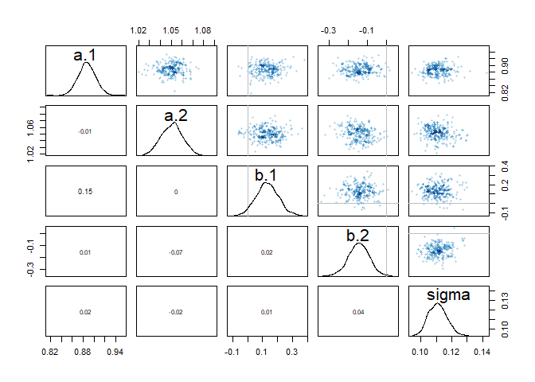

```r
## R code 9.17
pairs( m9.1_cauchy_0.1 )
```

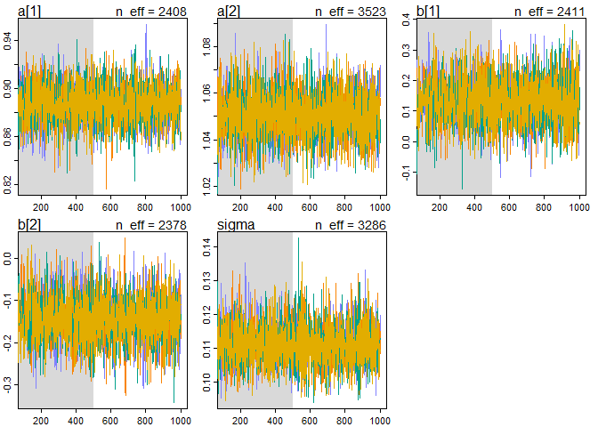

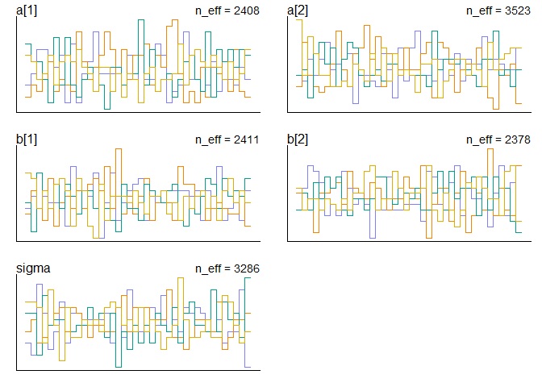

```r
## R code 9.18
traceplot( m9.1_cauchy_0.1 )

trankplot( m9.1_cauchy_0.1 , n_cols=2 )
```

```r
## R code 9.14
m9.1_cauchy_0.01 <- ulam(
    alist(
        log_gdp_std ~ dnorm( mu , sigma ) ,
        mu <- a[cid] + b[cid]*( rugged_std - 0.215 ) ,
        a[cid] ~ dnorm( 1 , 0.1 ) ,
        b[cid] ~ dnorm( 0 , 0.3 ) ,
        sigma ~ dcauchy( 0, 0.01 )
    ) ,
    data=dat_slim , chains=4 , cores=4 , iter=1000 )

## R code 9.15
show( m9.1_cauchy_0.01 )
```

```
## Hamiltonian Monte Carlo approximation
## 2000 samples from 4 chains
##
## Sampling durations (seconds):
##         warmup sample total
## chain:1   0.12   0.07  0.19
## chain:2   0.10   0.06  0.17
## chain:3   0.14   0.08  0.23
## chain:4   0.11   0.06  0.16
##
## Formula:
## log_gdp_std ~ dnorm(mu, sigma)
## mu <- a[cid] + b[cid] * (rugged_std - 0.215)
## a[cid] ~ dnorm(1, 0.1)
## b[cid] ~ dnorm(0, 0.3)
## sigma ~ dcauchy(0, 0.01)
```

```r
## R code 9.16
precis( m9.1_cauchy_0.01 , 2 )
```

```
##             mean          sd         5.5%       94.5%    n_eff      Rhat
## a[1]   0.8869167 0.016588620  0.860191068  0.91289639 2263.161 0.9990138
## a[2]   1.0503730 0.010395900  1.033351418  1.06647246 2852.642 0.9998075
## b[1]   0.1335435 0.078974433  0.005217984  0.25829415 2357.423 0.9990111
## b[2]  -0.1427813 0.056034566 -0.233934212 -0.05476347 2520.325 0.9994278
## sigma  0.1111945 0.006281844  0.101635355  0.12198727 2730.227 0.9998560
```

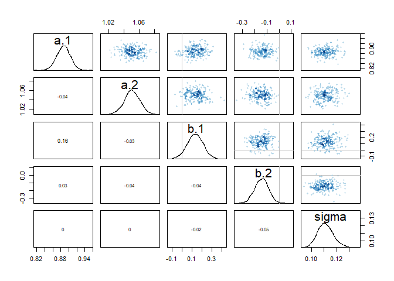

```r
## R code 9.17
pairs( m9.1_cauchy_0.01 )
```

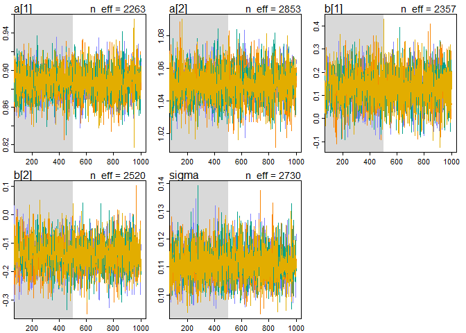

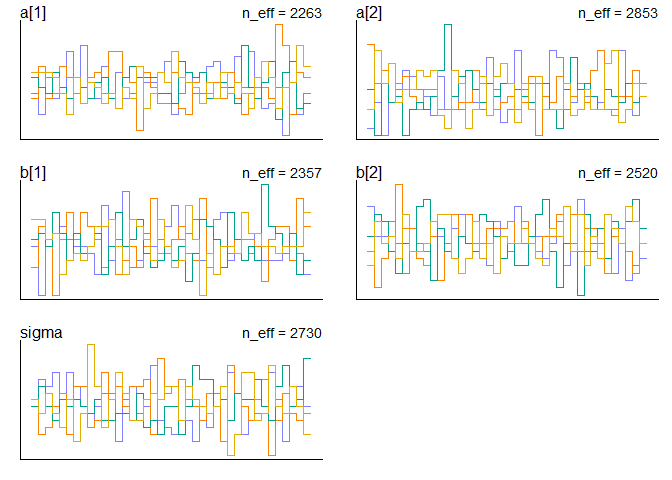

```r
## R code 9.18
traceplot( m9.1_cauchy_0.01 )

trankplot( m9.1_cauchy_0.01 , n_cols=2 )
```

### 8M3. Re-estimate one of the Stan models from the chapter, but at different numbers of warmup iterations. Be sure to use the same number of sampling iterations in each case. Compare the n_eff values. How much warmup is enough?

```r
## R code 9.14
m9.1 <- ulam(
    alist(
        log_gdp_std ~ dnorm( mu , sigma ) ,
        mu <- a[cid] + b[cid]*( rugged_std - 0.215 ) ,
        a[cid] ~ dnorm( 1 , 0.1 ) ,
        b[cid] ~ dnorm( 0 , 0.3 ) ,
        sigma ~ dexp( 1 )
    ) ,
    data=dat_slim , chains=4 , cores=4 , iter=1000 )
```

```
## recompiling to avoid crashing R session
```

```r
## R code 9.15
show( m9.1 )
```

```
## Hamiltonian Monte Carlo approximation
## 2000 samples from 4 chains
##
## Sampling durations (seconds):
##         warmup sample total
## chain:1   0.10   0.08  0.19
## chain:2   0.14   0.11  0.25
## chain:3   0.12   0.07  0.19
## chain:4   0.10   0.07  0.17
##
## Formula:
## log_gdp_std ~ dnorm(mu, sigma)
## mu <- a[cid] + b[cid] * (rugged_std - 0.215)
## a[cid] ~ dnorm(1, 0.1)
## b[cid] ~ dnorm(0, 0.3)
## sigma ~ dexp(1)
```

```r
## R code 9.16
precis( m9.1 , 2 )
```

```
##             mean          sd        5.5%       94.5%    n_eff      Rhat
## a[1]   0.8866864 0.016081462  0.86119771  0.91238117 2479.849 0.9995532
## a[2]   1.0506342 0.009981776  1.03465351  1.06687158 3086.514 0.9986569
## b[1]   0.1317209 0.076293712  0.00864851  0.25541803 2812.326 1.0000048
## b[2]  -0.1436872 0.055861290 -0.22979434 -0.05316767 3005.640 0.9992442
## sigma  0.1115027 0.006137147  0.10229557  0.12142451 2279.156 1.0001135
```

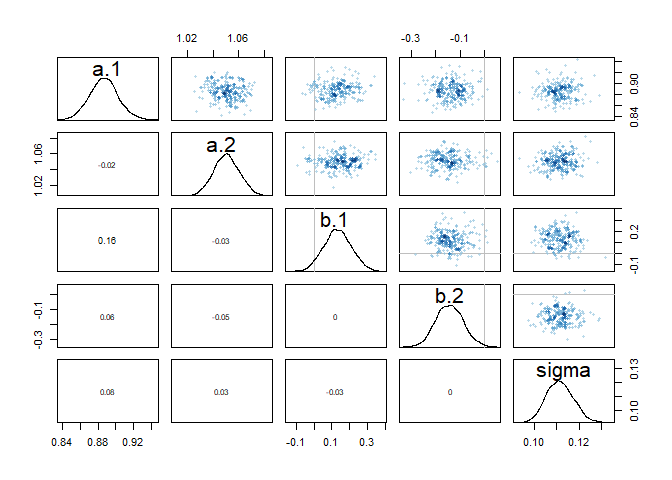

```r
## R code 9.17
pairs( m9.1 )
```

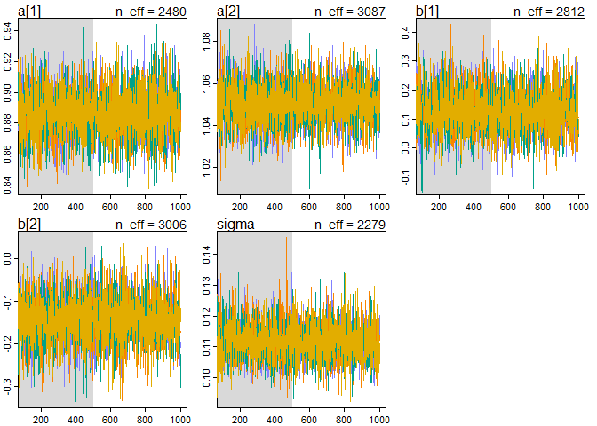

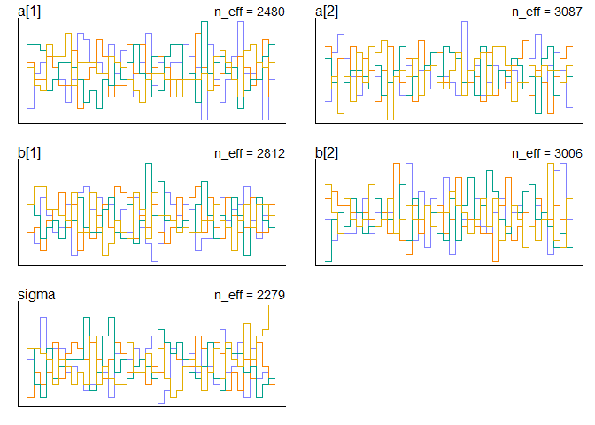

```r
## R code 9.18
traceplot( m9.1 )
trankplot( m9.1 , n_cols=2 )
```

```r
m9.1_test100 <- ulam(
    alist(
        log_gdp_std ~ dnorm( mu , sigma ) ,
        mu <- a[cid] + b[cid]*( rugged_std - 0.215 ) ,
        a[cid] ~ dnorm( 1 , 0.1 ) ,
        b[cid] ~ dnorm( 0 , 0.3 ) ,
        sigma ~ dexp( 1 )
    ) ,
    data=dat_slim , chains=4 , cores=4 , warmup=100 , iter=1000 )
```

```
## recompiling to avoid crashing R session
```

```r
## R code 9.15
show( m9.1_test100 )
```

```
## Hamiltonian Monte Carlo approximation
## 3600 samples from 4 chains
##
## Sampling durations (seconds):
##         warmup sample total
## chain:1   0.03   0.36  0.39
## chain:2   0.03   0.52  0.55
## chain:3   0.03   0.30  0.32
## chain:4   0.02   0.36  0.38
##
## Formula:
## log_gdp_std ~ dnorm(mu, sigma)
## mu <- a[cid] + b[cid] * (rugged_std - 0.215)
## a[cid] ~ dnorm(1, 0.1)
## b[cid] ~ dnorm(0, 0.3)
## sigma ~ dexp(1)
```

```r
## R code 9.16
precis( m9.1_test100 , 2 )
```

```
##             mean          sd        5.5%       94.5%    n_eff      Rhat
## a[1]   0.8865618 0.015902374  0.86173768  0.91267053 4130.342 0.9993226
## a[2]   1.0503899 0.010211543  1.03396098  1.06640003 3953.485 1.0005718
## b[1]   0.1317528 0.076812960  0.01279993  0.25358496 1462.623 1.0001165
## b[2]  -0.1439434 0.057424402 -0.23544159 -0.05213057 2344.412 1.0023903
## sigma  0.1114446 0.006026755  0.10218372  0.12150605 2133.988 1.0019303
```

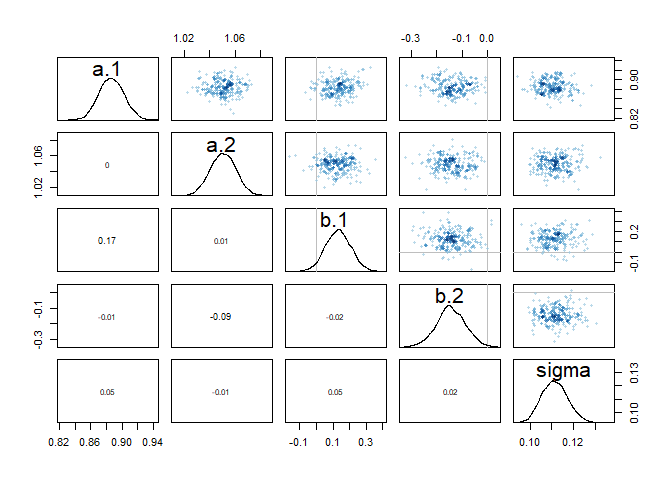

```r
## R code 9.17
pairs( m9.1_test100 )
```

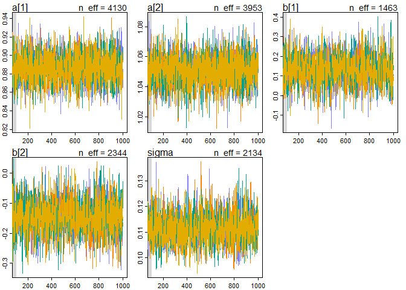

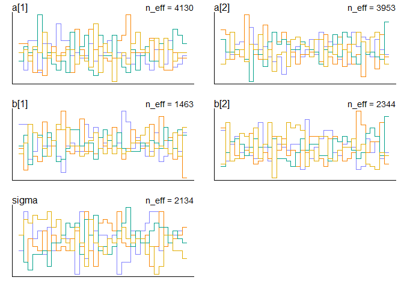

```r
## R code 9.18
traceplot( m9.1_test100 )
trankplot( m9.1_test100 , n_cols=2 )
```

```r
m9.1_test10 <- ulam(
    alist(
        log_gdp_std ~ dnorm( mu , sigma ) ,
        mu <- a[cid] + b[cid]*( rugged_std - 0.215 ) ,
        a[cid] ~ dnorm( 1 , 0.1 ) ,
        b[cid] ~ dnorm( 0 , 0.3 ) ,
        sigma ~ dexp( 1 )
    ) ,
    data=dat_slim , chains=4 , cores=4 , warmup=10 , iter=1000 )
```

```
## recompiling to avoid crashing R session
```

```r
## R code 9.15
show( m9.1_test10 )
```

```
## Hamiltonian Monte Carlo approximation
## 3960 samples from 4 chains
##
## Sampling durations (seconds):
##         warmup sample total
## chain:1      0   0.37  0.38
## chain:2      0   0.18  0.18
## chain:3      0   0.12  0.12
## chain:4      0   0.40  0.40
##
## Formula:
## log_gdp_std ~ dnorm(mu, sigma)
## mu <- a[cid] + b[cid] * (rugged_std - 0.215)
## a[cid] ~ dnorm(1, 0.1)
## b[cid] ~ dnorm(0, 0.3)
## sigma ~ dexp(1)
```

```r
## R code 9.16
precis( m9.1_test10 , 2 )
```

```
##             mean          sd         5.5%       94.5%     n_eff     Rhat
## a[1]   0.8863864 0.016053126  0.860027191  0.91126493 1865.0743 1.000983
## a[2]   1.0510611 0.010832637  1.034033238  1.06977479  956.8407 1.005474
## b[1]   0.1262008 0.089472039  0.001728146  0.24952994  259.4341 1.007068
## b[2]  -0.1449254 0.060546845 -0.231041773 -0.05420227  416.8806 1.012469
## sigma  0.1120250 0.007179053  0.102430184  0.12216103  419.5310 1.017851
```

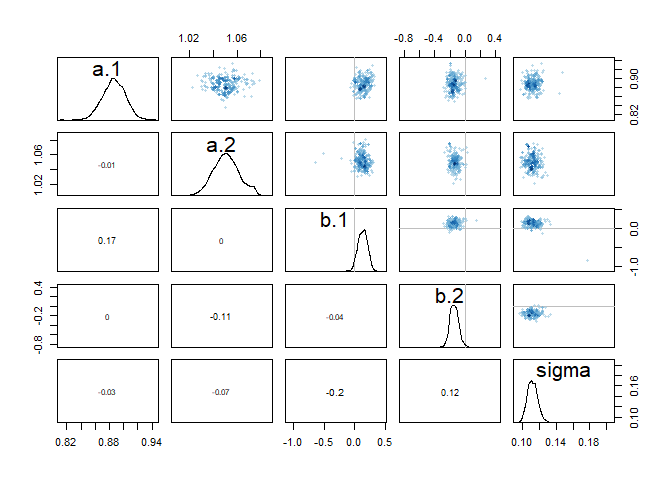

```r
## R code 9.17
pairs( m9.1_test10 )
```

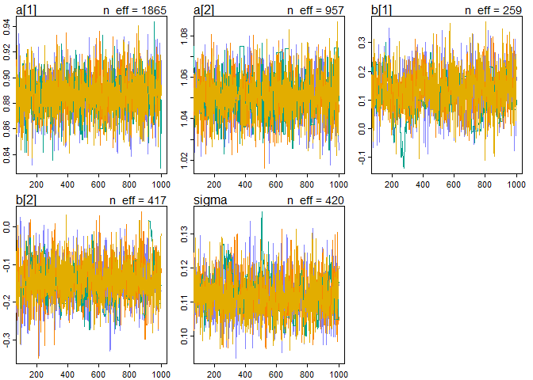

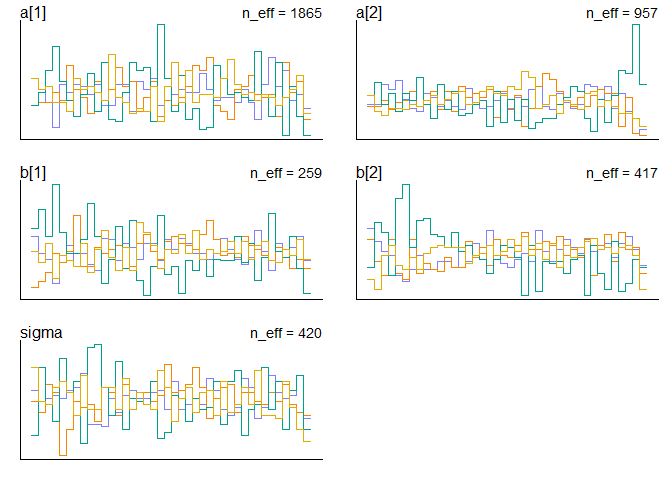

```r
## R code 9.18
traceplot( m9.1_test10 )
trankplot( m9.1_test10 , n_cols=2 )
```

```r
m9.1_test5 <- ulam(
    alist(
        log_gdp_std ~ dnorm( mu , sigma ) ,
        mu <- a[cid] + b[cid]*( rugged_std - 0.215 ) ,
        a[cid] ~ dnorm( 1 , 0.1 ) ,
        b[cid] ~ dnorm( 0 , 0.3 ) ,
        sigma ~ dexp( 1 )
    ) ,
    data=dat_slim , chains=4 , cores=4 , warmup=5 , iter=1000 )
```

```
## recompiling to avoid crashing R session
```

```r
## R code 9.15
show( m9.1_test5 )
```

```
## Hamiltonian Monte Carlo approximation
## 3980 samples from 4 chains
##
## Sampling durations (seconds):
##         warmup sample total
## chain:1      0   0.04  0.04
## chain:2      0   0.08  0.08
## chain:3      0   0.07  0.07
## chain:4      0   0.05  0.06
##
## Formula:
## log_gdp_std ~ dnorm(mu, sigma)
## mu <- a[cid] + b[cid] * (rugged_std - 0.215)
## a[cid] ~ dnorm(1, 0.1)
## b[cid] ~ dnorm(0, 0.3)
## sigma ~ dexp(1)
```

```r
## R code 9.16
precis( m9.1_test5 , 2 )
```

```
##              mean         sd       5.5%     94.5%    n_eff      Rhat
## a[1]   0.84849233 0.05890107  0.7699806 0.9182694 3.069281  1.848115
## a[2]   0.95961101 0.15132650  0.6983222 1.0670722      NaN 15.366974
## b[1]  -0.04984647 0.29685200 -0.2907690 0.2824541 2.913386  2.298334
## b[2]   0.06126341 0.21797049 -0.2333207 0.3336027 3.557711  1.961947
## sigma  0.18124083 0.08446780  0.1061315 0.2976352 2.835213  1.927073
```

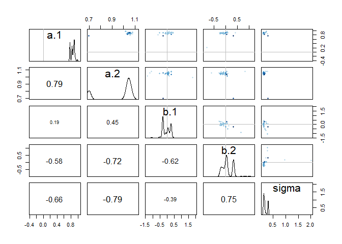

```r
## R code 9.17
pairs( m9.1_test5 )
```

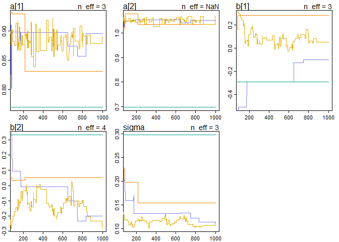

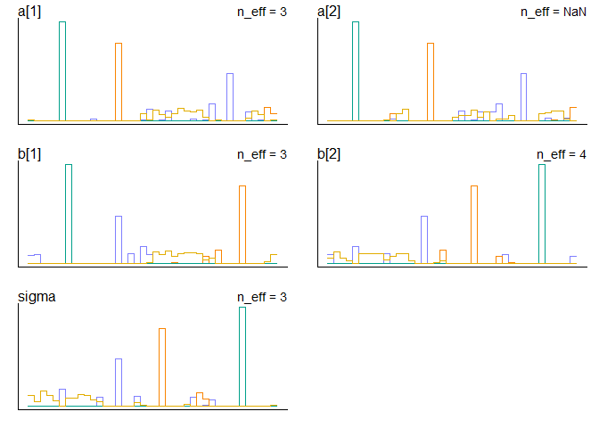

```r
## R code 9.18
traceplot( m9.1_test5 )
trankplot( m9.1_test5 , n_cols=2 )
```

```r
m9.1_test1 <- ulam(
    alist(
        log_gdp_std ~ dnorm( mu , sigma ) ,
        mu <- a[cid] + b[cid]*( rugged_std - 0.215 ) ,
        a[cid] ~ dnorm( 1 , 0.1 ) ,
        b[cid] ~ dnorm( 0 , 0.3 ) ,
        sigma ~ dexp( 1 )
    ) ,
    data=dat_slim , chains=4 , cores=4 , warmup=1 , iter=1000 )
```

```
## recompiling to avoid crashing R session
```

```r
## R code 9.15
show( m9.1_test1 )
```

```
## Hamiltonian Monte Carlo approximation
## 3996 samples from 4 chains
##
## Sampling durations (seconds):
##         warmup sample total
## chain:1      0   0.59  0.59
## chain:2      0   0.03  0.03
## chain:3      0   0.39  0.39
## chain:4      0   0.03  0.03
##
## Formula:
## log_gdp_std ~ dnorm(mu, sigma)
## mu <- a[cid] + b[cid] * (rugged_std - 0.215)
## a[cid] ~ dnorm(1, 0.1)
## b[cid] ~ dnorm(0, 0.3)
## sigma ~ dexp(1)
```

```r
## R code 9.16
precis( m9.1_test1 , 2 )
```

```
##             mean        sd       5.5%     94.5%    n_eff         Rhat
## a[1]  0.97550293 0.2033370  0.7052949 1.1992500      NaN 2.143483e+14
## a[2]  0.24552173 0.3979171 -0.1882376 0.7513262 2.003008 4.227211e+14
## b[1]  0.05363873 1.0826995 -0.9858384 1.8714126 2.003008 4.701718e+14
## b[2]  0.20096050 0.6598170 -0.7624039 0.9507326 2.003008 6.098494e+14
## sigma 0.82457984 0.4683709  0.2141496 1.4641239 2.003008 4.639905e+14
```

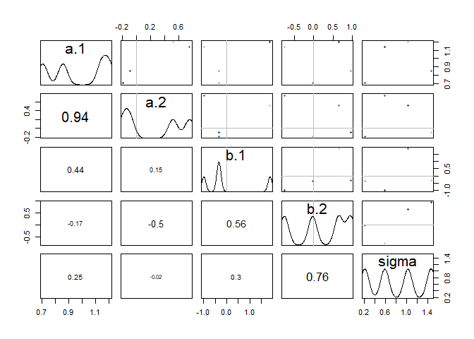

```r
## R code 9.17
pairs( m9.1_test1 )
```

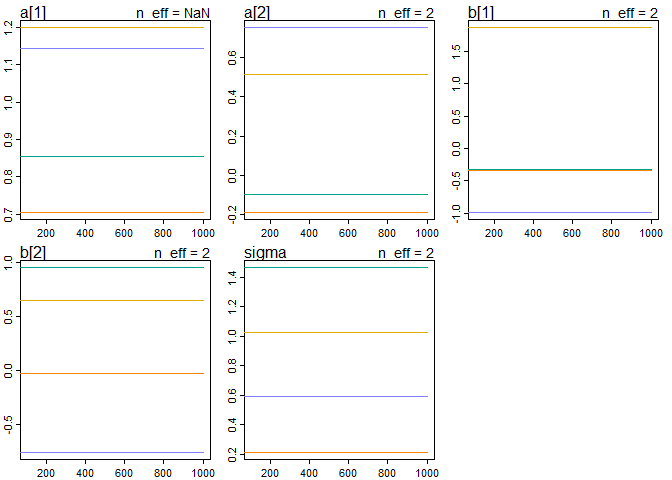

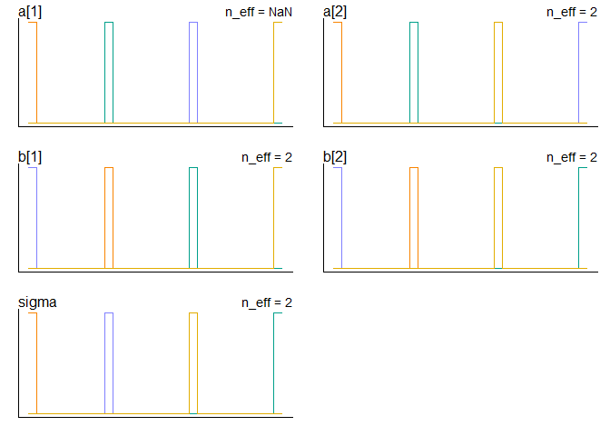

```r
## R code 9.18
traceplot( m9.1_test1 )
trankplot( m9.1_test1 , n_cols=2 )
```

> warmup = 100 is fine, but less than that. The problem shows up.

#### 8H1. Run the model below and then inspect the posterior distribution and explain what it is accomplishing.

```r
## R code 9.25
mp <- ulam(
    alist(
        a ~ dnorm(0,1),
        b ~ dcauchy(0,1)
    ),
    data=list(y=1),
    start=list(a=0,b=0),
    iter=1e4, warmup=100, chains = 4, cores = 4)
## R code 9.15
show( mp )
```

```
## Hamiltonian Monte Carlo approximation
## 39600 samples from 4 chains
##
## Sampling durations (seconds):
##         warmup sample total
## chain:1   0.00   0.90  0.90
## chain:2   0.00   0.69  0.70
## chain:3   0.00   0.62  0.62
## chain:4   0.01   0.52  0.53
##
## Formula:
## a ~ dnorm(0, 1)
## b ~ dcauchy(0, 1)
```

```r
## R code 9.16
precis( mp , 2 )
```

```
##           mean          sd      5.5%    94.5%      n_eff     Rhat
## a  0.002766864   0.9962504 -1.589014 1.582553 28042.3241 1.000078
## b -4.208111888 120.1570831 -5.754417 5.364262   707.5147 1.005741
```

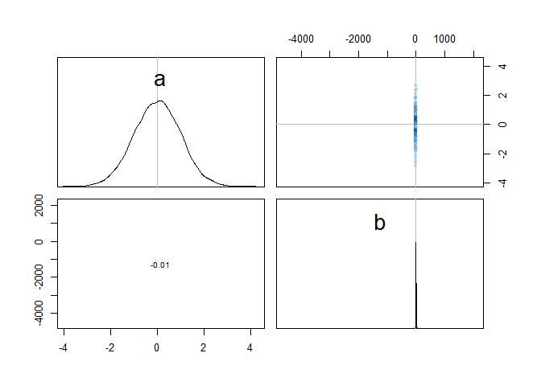

```r
## R code 9.17
pairs( mp )
```

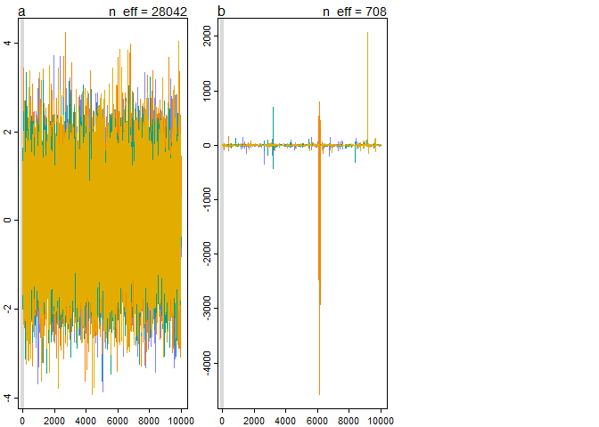

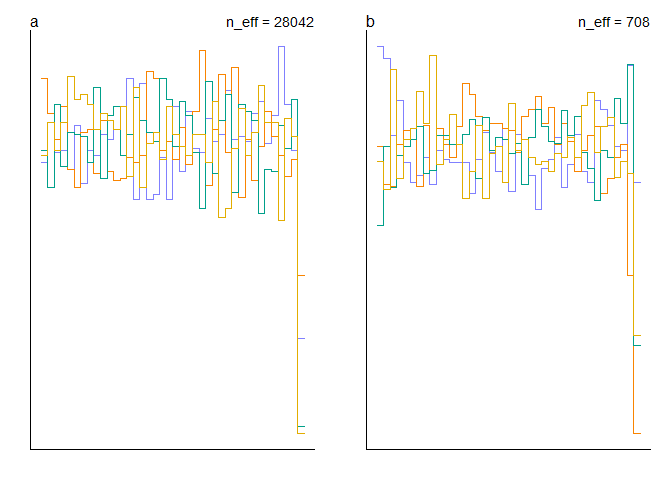

```r
## R code 9.18
traceplot( mp )
trankplot( mp , n_cols=2 )
```

#### Compare the samples for the parameters a and b. Can you explain the different trace plots, using what you know about the Cauchy distribution?

#### 8H2. Recall the divorce rate example from Chapter 5. Repeat that analysis, using ulam this time, fitting models m5.1, m5.2, and m5.3. Use compare to compare the models on the basis of WAIC. Explain the results.

### 8H3. Sometimes changing a prior for one parameter has unanticipated effects on other parameters. This is because when a parameter is highly correlated with another parameter in the posterior, the prior influences both parameters. Here’s an example to work and think through.

Go back to the leg length example in Chapter 5. Here is the code again, which simulates height and leg lengths for 100 imagined individuals:

```r
## R code 9.26
N <- 100                          # number of individuals
height <- rnorm(N,10,2)           # sim total height of each
leg_prop <- runif(N,0.4,0.5)      # leg as proportion of height
leg_left <- leg_prop*height +     # sim left leg as proportion + error
    rnorm( N , 0 , 0.02 )
leg_right <- leg_prop*height +    # sim right leg as proportion + error
    rnorm( N , 0 , 0.02 )
                                  # combine into data frame
d <- data.frame(height,leg_left,leg_right)
```

And below is the model you fit before, resulting in a highly correlated posterior for the two beta parameters. This time, fit the model using map2stan:

```r
## R code 9.27
m5.8s <- map2stan(
    alist(
        height ~ dnorm( mu , sigma ) ,
        mu <- a + bl*leg_left + br*leg_right ,
        a ~ dnorm( 10 , 100 ) ,
        bl ~ dnorm( 2 , 10 ) ,
        br ~ dnorm( 2 , 10 ) ,
        sigma ~ dcauchy( 0 , 1 )
    ) ,
    data=d, chains=4,
    #log_lik = TRUE,
    start=list(a=10,bl=0,br=0,sigma=1) )
```

```
## Computing WAIC
```

Compare the posterior distribution produced by the code above to the posterior distribution pro- duced when you change the prior for br so that it is strictly positive:

```r
## R code 9.28
m5.8s2 <- map2stan(
    alist(
        height ~ dnorm( mu , sigma ) ,
        mu <- a + bl*leg_left + br*leg_right ,
        a ~ dnorm( 10 , 100 ) ,
        bl ~ dnorm( 2 , 10 ) ,
        br ~ dnorm( 2 , 10 ) & T[0,] ,
        sigma ~ dcauchy( 0 , 1 )
    ) ,
    data=d, chains=4,
    #log_lik = TRUE,
    start=list(a=10,bl=0,br=0,sigma=1) )
```

```
## Computing WAIC
```

Note that T[0,] on the right-hand side of the prior for br. What the T[0,] does is truncate the normal distribution so that it has positive probability only above zero. In other words, that prior ensures that the posterior distribution for br will have no probability mass below zero. Compare the two posterior distributions for m5.8s and m5.8s2. What has changed in the posterior distribution of both beta parameters? Can you explain the change induced by the change in prior?

```r
#plot(m5.8s)
#plot(m5.8s2)

## R code 9.15
show( m5.8s )
```

```
## map2stan model
## 4000 samples from 4 chains
##
## Sampling durations (seconds):
##         warmup sample total
## chain:1   7.15   7.68 14.83
## chain:2   7.43   7.73 15.17
## chain:3   7.21   8.22 15.43
## chain:4   6.98   7.80 14.78
##
## Formula:
## height ~ dnorm(mu, sigma)
## mu <- a + bl * leg_left + br * leg_right
## a ~ dnorm(10, 100)
## bl ~ dnorm(2, 10)
## br ~ dnorm(2, 10)
## sigma ~ dcauchy(0, 1)
##
## WAIC (SE): 186.66 (10.3)
## pWAIC: 3.35
```

```r
show( m5.8s2 )
```

```
## map2stan model
## 4000 samples from 4 chains
##
## Sampling durations (seconds):
##         warmup sample total
## chain:1   7.06   8.34 15.40
## chain:2   6.56   7.39 13.95
## chain:3   6.62   7.15 13.77
## chain:4   6.59   8.93 15.52
##
## Formula:
## height ~ dnorm(mu, sigma)
## mu <- a + bl * leg_left + br * leg_right
## a ~ dnorm(10, 100)
## bl ~ dnorm(2, 10)
## br ~ dnorm(2, 10) & T[0, ]
## sigma ~ dcauchy(0, 1)
##
## WAIC (SE): 186.13 (10.4)
## pWAIC: 3.12
```

```r
## R code 9.16
precis( m5.8s , 2 )
```

```
##             mean         sd       5.5%     94.5%    n_eff     Rhat
## a      0.6516675 0.31589505  0.1292020 1.1555987 2406.347 1.000174
## bl    -2.2170636 2.13217473 -5.6212222 1.1677972 1689.011 1.006328
## br     4.2987375 2.13074778  0.9158738 7.7049801 1694.590 1.006279
## sigma  0.6064281 0.04423898  0.5405831 0.6793522 2351.003 1.000238
```

```r
precis( m5.8s2 , 2 )
```

```
##             mean         sd       5.5%     94.5%    n_eff     Rhat
## a      0.6755852 0.29497458  0.1923812 1.1424747 1754.018 1.002044
## bl    -2.2575334 1.95863300 -5.5127894 0.8550063 1315.015 1.002174
## br     4.3342417 1.95820643  1.2345441 7.5913901 1320.964 1.002157
## sigma  0.6061283 0.04450378  0.5403171 0.6827886 2119.273 1.000034
```

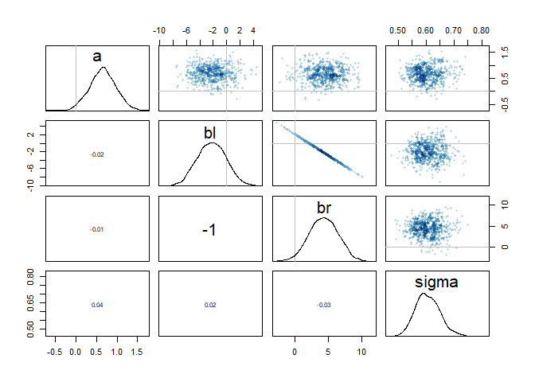

```r
## R code 9.17
pairs( m5.8s )
```

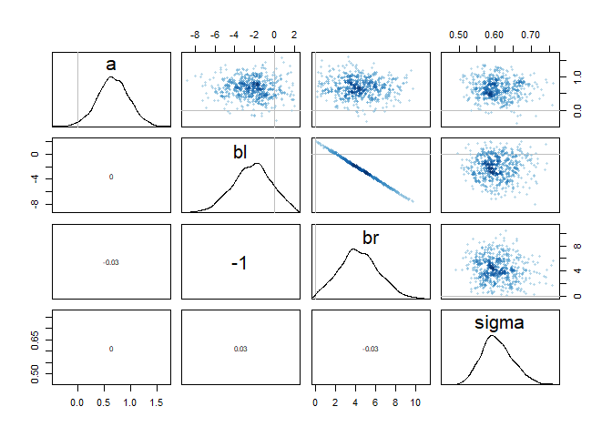

```r
pairs( m5.8s2 )
```

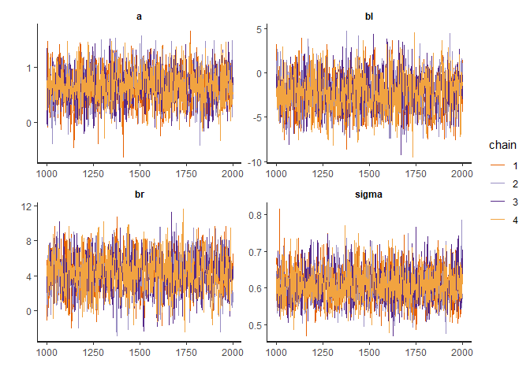

```r
trankplot(m5.8s)

plotchains(m5.8s)
trankplot(m5.8s2)
```

[output not shown]

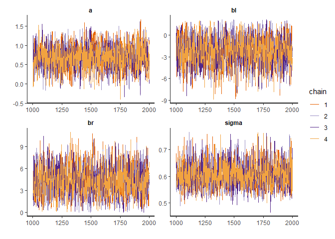

```r
plotchains(m5.8s2)
#coeftab(m5.8s, m5.8s2)
compare(m5.8s, m5.8s2)
```

[output not shown]

### 8H4. For the two models fit in the previous problem, use DIC or WAIC to compare the effective numbers of parameters for each model. Which model has more effective parameters? Why?

```r
compare(m5.8s, m5.8s2)
```

```
##           WAIC    pWAIC     dWAIC    weight       SE       dSE
## m5.8s2 186.131 3.118123 0.0000000 0.5658699 10.35666        NA
## m5.8s  186.661 3.353227 0.5300399 0.4341301 10.34286 0.1783166
```

```r
WAIC(m5.8s)
```

```
## [1] 186.661
## attr(,"lppd")
## [1] -89.97729
## attr(,"pWAIC")
## [1] 3.353227
## attr(,"se")
## [1] 10.34286
```

```r
WAIC(m5.8s2)
```

```
## [1] 186.131
## attr(,"lppd")
## [1] -89.94738
## attr(,"pWAIC")
## [1] 3.118123
## attr(,"se")
## [1] 10.35666
```

> Effective number of parameters for the second model is smaller. pWAIC is defined as sum of variance of the points likelihood, thus the second model has smaller variance of data likelihood, ‘more restricted’